# manual

Yujie Wu

2022-03-30

## Manual

This file contains detailed procedure for reproducing the results presented in the paper `A Pairwise Imputation Strategy for Retaining Predictive Features When Combining Multiple Datasets’.

### Reproducing the simulation results in Section 3.1.1 when all covariates are predictive of the outcome

The generate_simple() function is used to generate data following Equation (1) of the main paper. The parameters numx controls the number of X’s that are common to all studies; numxs controls the number of $X*$’s that may be missing systematically across studies; XY controls the magnitude of the coefficients corresponding to X’s, and XSY controls the magnitude of the coefficients corresponding to $X^\ast$’s.

The multiple_simple() function first performs the Omitting, pairwise linear/polynomial imputation and merged linear/polynomial imputation methods to impute the missing covariates in the training sets, and then run the LASSO regression on the merged imputed training sets to make predictions on the testing set. The paramter sim.iter controls the number of iteration to be performed, and non.miss.num controls the number of $X_3,\ldots,X_5,X_1^\ast,\ldots,X_5^\ast$’s in each training set.

The wilcox.simple() function takes the output from multiple_simple() and performs the pairwise Wilcoxon rank sum test of the prediction RMSE between different imputation methods. The parameter miss.no specifies the number of missing genes in each training set, where miss.no = (numx+numxs-2)-non.miss.num. In the plot, a red line indicates that the p-value from the paired Wilcoxon test is less than 0.01; a green line indicates that the p-value is greater than 0.01 but less than 0.05; and a blue line indicates that the p-value is greater than 0.05; and the method to which the arrow is pointing has a significantly smaller median RMSE. The number above each method presents the proportion of times each method has the smallest prediction RMSE in the validation set across the overall simulation replicates.

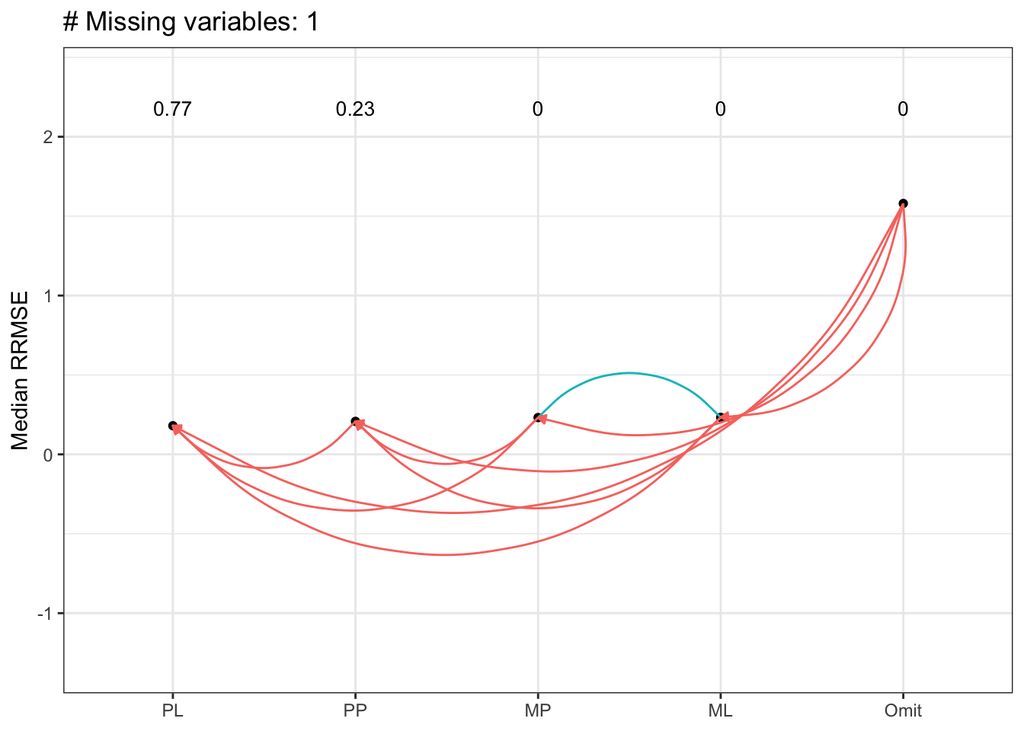

```r
MSE1 <-  multiple_simple(numx=5, numxs=5, XY="Medium", XSY="Medium",
                  non.miss.num=7, sim.iter = 30)
print(wilcox.simple(MSE1$MSE, 1))
```

### Reproducing the simulation results in Section 3.1.1 when there exist noise

The function signal_data() is used to generate $X$ and $X^\ast$’s that are predictive of the outcome as the function generate_simple(). noise_data() generates the covariates that are irrelevant to the outcome and independent of the signals, where the parameter number controls the number of irrelevant genes in each study.

The multiple_sparse() function first performs the Omitting, pairwise linear/polynomial imputation and merged linear/polynomial imputation methods to impute the missing covariates in the training sets, and then run the LASSO regression on the merged imputed training sets to make predictions on the testing set. The paramter sim.iter controls the number of iteration to be performed, xxs.non.miss.num controls the number of $X_3,\ldots,X_5,X_1^\ast,\ldots,X_5^\ast$’s in each training set, and noise.non.miss.num controls the number of noises in each training set.

The wilcox.sparse() function takes the output from multiple_sparse() and performs the pairwise Wilcoxon rank sum test of the prediction RMSE between different imputation methods. The parameter miss.x specifies the number of missing predictive genes (including $X$ and $X^\ast$) in each training set, where miss.x = (numx+numxs-2)-xxs.non.miss.num. Moreover, miss.n specifies the number of missing irrelevant genes in each training set, where miss.n = number - noise.non.miss.num.

In the plot, a red line indicates that the p-value from the paired Wilcoxon test is less than 0.01; a green line indicates that the p-value is greater than 0.01 but less than 0.05; and a blue line indicates that the p-value is greater than 0.05; and the method to which the arrow is pointing has a significantly smaller median RMSE. The number above each method presents the proportion of times each method has the smallest prediction RMSE in the validation set across the overall simulation replicates.

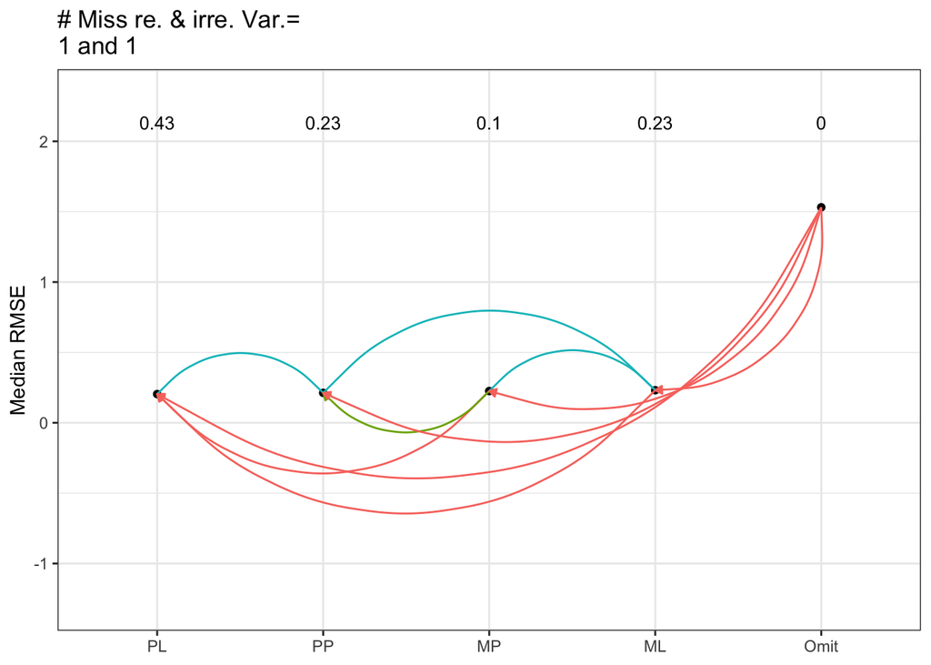

```r
MSE1.noise <-  multiple_sparse(numx=5, numxs=5, numnoise = 5, XY="Medium", XSY="Medium", xxs.non.miss.num= 7, noise.non.miss.num = 4, sim.iter = 30)
print(wilcox.sparse(MSE1.noise$MSE, 1, 1))
```